# 德国信贷风控数据建模（进阶4：多模型集成学习 vs 融合学习）

### Python金融风控策略实战（基于Jupyter Notebook）

## 德国信贷风控数据建模

## （进阶4：多模型集成学习 vs 融合学习）

### 策略制定及验证：张君颖 ； 报告日期：2020.11.30

本报告不构成投资建议，转载需注明作者且不得删改

作者邮箱：zhang.jun.ying@outlook.com

### 1. 集成学习 vs 融合学习

集成学习，在既定的设计框架下，通过并行 or 串行的方式，让数据在多个基模型中进行预测，然后通过对多个模型的预测结果进行概率投票/标签投票等方式，得到最终的预测结果。最终集成的模型是由多个基模型加权得到的。

融合学习，相对集成学习更加灵活，通过采用不同的基学习器进行模型组合，自定义的空间更多，缺点是目前在 scikit-learn 库中，并不提供现成的函数包，需要自行在 Github 上找对应的 library。

#### =========== 集成学习 ===========

并行学习框架 Bagging ，可以让多个基模型同时进行建模，模型之间相互独立，没有先后顺序；典型代表：随机森林（Random Forest），其中的基模型均为 DT 决策树模型。

串行学习框架 Boosting ，各个基模型之间有强烈的依赖关系，即后一个模型是在前一个模型的基础上建立的。典型代表：AdaBoost模型 ——> GBDT 梯度提升决策树 / GBRT 梯度提升回归树 ——> Xgboost模型

******不同集成学习模型增加扰动策略汇总******

| 模型 | 数据扰动 | 属性扰动 | 样本权重扰动 | 输出扰动 | 算法扰动 |
| --- | --- | --- | --- | --- | --- |
| Random Forest 模型 | √ | √ | X | X | √ |
| Adaboost 模型 | X | X | √ | X | √ |
| GBDT 模型 | √ | √ | X | √ | √ |
| Xgboost 模型 | √ | √ | X | √ | √ |

#### =========== 融合学习 ===========

融合学习分两种数据组合方法：Blending 混合法、Stacking 叠加法。

Blending 混合法 ：将训练集数据分为 A、B 上下两层，先用 A 数据进行一级建模，然后让 B 数据套入一级模型中，输出的结果作为新数据，再进行二级建模。与此同时，测试集数据先套入一级模型中，输出成新的测试数据，再将数据套入二级模型中，输出最终的预测结果。

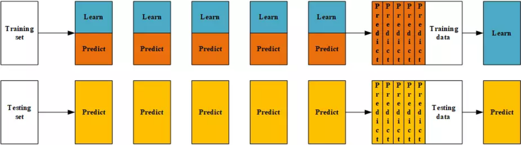

Stacking 叠加法 ：将训练集数据先进行一级建模，形成新的训练集数据，然后让原训练集数据“叠加”新数据，一起进行二级建模。与此同时，测试集数据，先进入一级模型，生成新的测试数据，然后让原测试集数据“叠加”新数据，一起套入二级模型中，输出最终的预测结果。

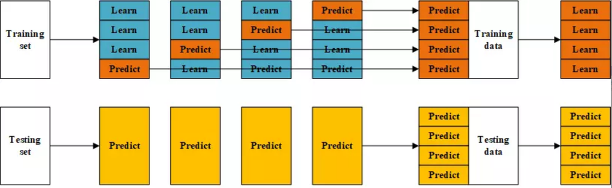

### 2. 集成学习，并行 Bagging 框架 —> 随机森林（Random Forest）实战

建模步骤：

1. 给定构建 M 个基学习器与属性采样比率，随机选取属性；
2. 采用自助采样法从原始训练集中得到 M 个与原始训练样本数量相同的样本子集；
3. 分别在 M 个样本子集中训练 M 个基学习器；
4. 集成策略：对于回归模型采用简单的等权重加和，对于分类模型采用相对多数投票方法。

**评估指标**  
分类问题：基尼系数（Gini在决策树中应用最广泛的是CART模型）、信息增益（entropy常用于ID3模型）等  
回归问题：均方误差（MSE）、平均绝对误差（MAE）等

```python
import os
import sys
import pandas as pd
import numpy as np
import warnings
warnings.filterwarnings("ignore") ##忽略警
from sklearn.model_selection import train_test_split
import variable_encode as var_encode
from sklearn.metrics import confusion_matrix,recall_score, auc, roc_curve,precision_score,accuracy_score
from sklearn.model_selection import GridSearchCV
from sklearn.preprocessing import StandardScaler
from sklearn.svm import SVC
from sklearn.linear_model import LogisticRegression
from sklearn.ensemble import RandomForestClassifier
from sklearn.ensemble import AdaBoostClassifier
from sklearn.ensemble import GradientBoostingClassifier
from xgboost import XGBClassifier
from sklearn.model_selection import KFold
import matplotlib.pyplot as plt
import matplotlib
matplotlib.rcParams['font.sans-serif']=['SimHei']
matplotlib.rcParams['axes.unicode_minus']=False
%matplotlib inline
```

```python
def data_read(data_path,file_name):
    df = pd.read_csv( os.path.join(data_path, file_name), delim_whitespace = True, header = None )
    columns = ['status_account','duration','credit_history','purpose', 'amount',
               'svaing_account', 'present_emp', 'income_rate', 'personal_status',
               'other_debtors', 'residence_info', 'property', 'age',
               'inst_plans', 'housing', 'num_credits',
               'job', 'dependents', 'telephone', 'foreign_worker', 'target']
    df.columns = columns
    # 将标签变量由状态1,2转为0,1; 其中0表示好信用，1表示坏信用
    df.target = df.target - 1
    # 将数据分为data_train（训练集）和 data_test（测试集）两部分
    # 按目标变量进行分层抽样，即训练集和测试集中，好坏样本的比例相同。
    data_train, data_test = train_test_split(df, test_size=0.2, random_state=0,stratify=df.target)
    # 由于训练集、测试集是随机划分，索引是乱的，需要重新排序
    data_train = data_train.reset_index(drop=True)
    data_test = data_test.reset_index(drop=True)
    return data_train, data_test
```

```python
## 离散变量与连续变量区分
def category_continue_separation(df,feature_names):
    categorical_var = []
    numerical_var = []
    if 'target' in feature_names:
        feature_names.remove('target')
    ##先判断类型，如果是int或float就直接作为连续变量
    numerical_var = list(df[feature_names].select_dtypes(include=['int','float','int32','float32','int64','float64']).columns.values)
    categorical_var = [x for x in feature_names if x not in numerical_var]
    return categorical_var,numerical_var
if __name__ == '__main__':
    data_path = os.path.join('C:\\Users\\lotbear\\Desktop\\Data-science！','金融风控实战数据')
    file_name = 'german.csv'
    ##读取数据
    data_train, data_test = data_read(data_path,file_name)
    sum(data_train.target ==0)
    data_train.target.sum()
    ##区分离散变量与连续变量
    feature_names = list(data_train.columns)
    feature_names.remove('target')
    categorical_var,numerical_var = category_continue_separation(data_train,feature_names)

    data_df = pd.concat([data_train,data_test],axis=0)
    data_df = data_df.reset_index(drop=True)
    x_data = data_df.loc[:,data_df.columns != 'target']
    y_data = data_df.target

print('原始数据中，好信用样本量：',sum( data_df.target == 0))
print('原始数据中，坏信用样本量：',sum( data_df.target == 1))
print('原始数据总样本量：',data_df.shape)
```

```
原始数据中，好信用样本量： 700
原始数据中，坏信用样本量： 300
原始数据总样本量： (1000, 21)
```

```python
## 离散变量直接WOE编码
var_all_bin = list(data_train.columns)
var_all_bin.remove('target')
##训练集WOE编码
df_train_woe, dict_woe_map, dict_iv_values ,var_woe_name = var_encode.woe_encode(data_train,
                                                                                 data_path,categorical_var,
                                                                                 data_train.target,'dict_woe_map', flag='train')
##测试集WOE编码
df_test_woe, var_woe_name = var_encode.woe_encode(data_test,data_path,categorical_var, data_test.target, 'dict_woe_map',flag='test')
```

```python
## 连续变量缺失值做填补
for i in numerical_var:
    if sum(data_train[i].isnull()) >0:
        data_train[i].fillna(data_train[i].mean(),inplace=True)
    if sum(data_test[i].isnull()) >0:
        data_test[i].fillna(data_test[i].mean(),inplace=True)
```

```python
## 组成分箱后的训练集与测试集
data_train.reset_index(drop=True,inplace=True)
data_test.reset_index(drop=True,inplace=True)
var_1 = numerical_var
var_1.append('target')
data_train_1 = pd.concat([df_train_woe[var_woe_name],data_train[var_1]],axis=1)
data_test_1 = pd.concat([df_test_woe[var_woe_name],data_test[var_1]],axis=1)
```

```python
## 取出训练数据与测试数据
var_all = list(data_train_1.columns)
var_all.remove('target')
## 变量归一化
scaler = StandardScaler().fit(data_train_1[var_all])
data_train_1[var_all] = scaler.transform(data_train_1[var_all])
data_test_1[var_all] = scaler.transform(data_test_1[var_all])
```

```python
x_train = np.array(data_train_1[var_all])
y_train = np.array(data_train_1.target)
x_test = np.array(data_test_1[var_all])
y_test = np.array(data_test_1.target)
```

```python
## 随机森林模型
## 设置待优化的超参数
rf_param = {'n_estimators': list(range(50, 400, 50)),
            'max_depth': list(range(2, 10, 1)),
            'class_weight': [{1: 1, 0: 1}, {1: 2, 0: 1}, {1: 3, 0: 1}]}
## 初始化网格搜索
rf_gsearch = GridSearchCV(estimator=RandomForestClassifier(random_state=0, criterion='entropy',
                                                            max_features=0.8, bootstrap=True),
                              param_grid=rf_param, cv=3, scoring='f1', n_jobs=-1, verbose=2)
## 执行超参数优化
rf_gsearch.fit(x_train, y_train)
print('随机森林模型最优得分 {0},\n最优参数{1}'.format(rf_gsearch.best_score_,rf_gsearch.best_params_))
```

```
Fitting 3 folds for each of 168 candidates, totalling 504 fits
```

```
[Parallel(n_jobs=-1)]: Using backend LokyBackend with 8 concurrent workers.
[Parallel(n_jobs=-1)]: Done  25 tasks      | elapsed:    4.0s
[Parallel(n_jobs=-1)]: Done 146 tasks      | elapsed:   12.9s
[Parallel(n_jobs=-1)]: Done 349 tasks      | elapsed:   27.6s
```

```
随机森林模型最优得分 0.6273735481672023,
最优参数{'class_weight': {1: 3, 0: 1}, 'max_depth': 6, 'n_estimators': 100}
```

```
[Parallel(n_jobs=-1)]: Done 504 out of 504 | elapsed:   40.7s finished
```

```python
## 模型训练
## 用最优参数，初始化随机森林模型
RF_model_2 = RandomForestClassifier(random_state=0, n_jobs=-1, criterion='entropy',
                                    n_estimators=rf_gsearch.best_params_['n_estimators'],
                                    max_depth=rf_gsearch.best_params_['max_depth'],
                                    max_features=0.8,
                                    min_samples_split=50,
                                    class_weight=rf_gsearch.best_params_['class_weight'],
                                    bootstrap=True)
## 训练随机森林模型
RF_model_2_fit = RF_model_2.fit(x_train, y_train)
```

```python
##  属性
#    ss = RF_model_2_fit.estimators_
#    RF_model_2_fit.classes_
#    RF_model_2_fit.n_features_
#    RF_model_2_fit.feature_importances_
```

```python
## 模型预测
y_pred = RF_model_2_fit.predict(x_test)
## 计算混淆矩阵与recall、precision
cnf_matrix = pd.DataFrame(data=confusion_matrix(y_test, y_pred),
                          columns=['预测结果为正例','预测结果为反例'],index=['真实样本为正例','真实样本为反例'])
recall_value = recall_score(y_test, y_pred)
precision_value = precision_score(y_test, y_pred)
acc = accuracy_score(y_test, y_pred)
print('随机森林模型的召回率：',recall_value)
print('随机森林模型的精准率：',precision_value)
print('随机森林模型预测的正确率:',acc)
print('='*80)
print('测试集的混淆矩阵：')
cnf_matrix
```

```
随机森林模型的召回率： 0.7666666666666667
随机森林模型的精准率： 0.46464646464646464
随机森林模型预测的正确率: 0.665
================================================================================
测试集的混淆矩阵：
```

|  | 预测结果为正例 | 预测结果为反例 |
| --- | --- | --- |
| 真实样本为正例 | 87 | 53 |
| 真实样本为反例 | 14 | 46 |

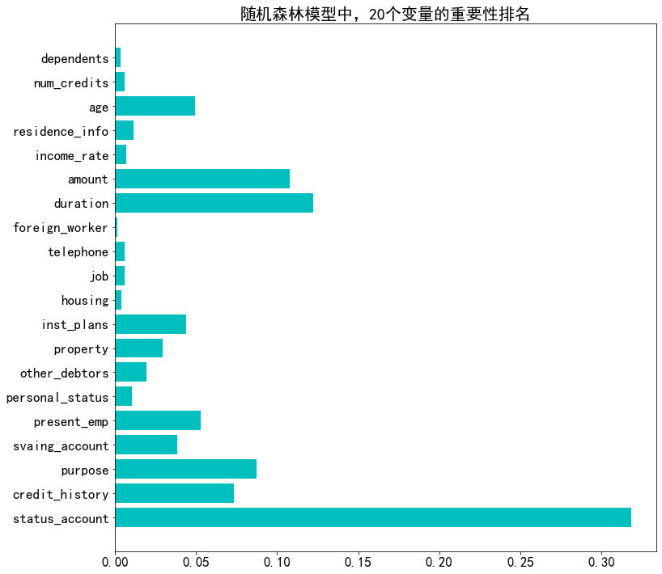

```python
## 变量重要性排序
## 取出变量重要性结果
len_1 = len(RF_model_2.feature_importances_)
var_name = [str(x).split('_woe')[0] for x in var_all]

## 重要性绘图
plt.figure(figsize=(12,12))
plt.barh(np.arange(0,20),RF_model_2.feature_importances_,color ='c',tick_label=var_name)
plt.xticks( fontsize=17)
plt.yticks( fontsize=17)
plt.title('随机森林模型中，20个变量的重要性排名',fontsize=20)
plt.show()
```

```python
IMAGES_PATH = os.path.join(".", "images", "Random_Forest_Model" )
os.makedirs(IMAGES_PATH, exist_ok=True)
# 定义存储图片函数，也可以保存成pdf图像
def save_fig(fig_id, tight_layout=True, fig_extension="png", resolution=300):
    path = os.path.join(IMAGES_PATH, fig_id + "." + fig_extension)
    # print("Saving figure", fig_id)
    if tight_layout:
        plt.tight_layout()
    plt.savefig(path, format=fig_extension, dpi=resolution)
```

```python
## 画出随机森林的决策树
from graphviz import Source
from sklearn.tree import export_graphviz
import pydotplus
from IPython.display import Image

# 有时候python会笨，找不到graphviz所在的环境，需要加一句
os.environ["PATH"] += os.pathsep + 'D:/Python/Ipython/Library/bin/graphviz'

PROJECT_ROOT_DIR = "."
CHAPTER_ID = "Random_Forest_Model"
# 当前路径下新建文件夹‘images’，文件夹里再新建文件夹（章节ID），整体作为图像路径
IMAGES_PATH = os.path.join(PROJECT_ROOT_DIR, "images", CHAPTER_ID)
os.makedirs(IMAGES_PATH, exist_ok=True)

# 随机森林是多棵决策树的组合，scikit-learn 没有直接的方法显示随机森林，只能拆解成单棵树来显示
Estimators = RF_model_2_fit.estimators_
for index, model in enumerate(Estimators): ## 枚举估计值
    filename = 'RF_' + str(index) + '.pdf'
    dot_data = export_graphviz(model, out_file=os.path.join(IMAGES_PATH,'RF_'+str(index)+'.dot'), # 共输出 100 棵拆解后的决策树
                         feature_names=var_all,
                         class_names=['Bad_credit','Good_credit'],
                         filled=True, rounded=True,special_characters=True)
    # graph = pydotplus.graph_from_dot_data(dot_data)
    # graph.write_pdf(filename) # 生成 100 张 PDF 决策树图
    # Image(graph.create_png())
```

#### 随机森林是多棵决策树的组合，scikit-learn 没有直接的方法显示随机森林，只能拆解成单棵树来显示

#### 为了可视化随机森林的分类过程，作者按每个估计量进行拆解，共拆出 100 棵决策树，下面显示其中 3 棵

```python
Source.from_file(os.path.join(IMAGES_PATH,'RF_'+'0'+'.dot'))
```

[figure not shown]

```python
Source.from_file(os.path.join(IMAGES_PATH,'RF_'+'50'+'.dot'))
```

[figure not shown]

```python
Source.from_file(os.path.join(IMAGES_PATH,'RF_'+'99'+'.dot'))
```

[figure not shown]

### 3. 集成学习，串行 Boosting 框架 —> Adaboost 模型实战

在 Adaboost 串行建模过程中，如何调整样本分布？如何确定模型的集成权重？

1. 针对前一轮模型预测错误的样本，增加被错误预测的样本权重，从而改变样本分布，让下一轮模型能更好地学习被错误预测的样本；
2. 对于不支持权重学习的算法，采用重采样的方法改变样本分布，比如加大被错误预测的样本的采样概率，减小正确样本采样概率；
3. 根据每轮学习器的性能指标，确定不同的权重进行加权集成。

```python
## Adaboost模型
## 设置待优化的超参数
ada_param = {'n_estimators': list(range(50, 500, 50)),
            'learning_rate': list(np.arange(0.1, 1, 0.2))}
## 初始化网格搜索
ada_gsearch = GridSearchCV(estimator=AdaBoostClassifier(algorithm='SAMME.R',random_state=0),
                            param_grid=ada_param, cv=3,  n_jobs=-1, verbose=2)
## 执行超参数优化
ada_gsearch.fit(x_train, y_train)
print('AdaBoost模型最优得分 {0},\n最优参数{1}'.format(ada_gsearch.best_score_,ada_gsearch.best_params_))
```

```
Fitting 3 folds for each of 45 candidates, totalling 135 fits
```

```
[Parallel(n_jobs=-1)]: Using backend LokyBackend with 8 concurrent workers.
[Parallel(n_jobs=-1)]: Done  34 tasks      | elapsed:    3.3s
[Parallel(n_jobs=-1)]: Done 135 out of 135 | elapsed:   12.6s finished
```

```
AdaBoost模型最优得分 0.7599804755334029,
最优参数{'learning_rate': 0.30000000000000004, 'n_estimators': 450}
```

```python
## 模型训练
## 用最优参数，初始化Adaboost模型
ada_model_2 = AdaBoostClassifier( n_estimators=ada_gsearch.best_params_['n_estimators'],
                                    learning_rate=ada_gsearch.best_params_['learning_rate'],
                                    algorithm='SAMME.R',random_state=0)
## 训练adaboost模型
ada_model_2_fit = ada_model_2.fit(x_train, y_train)
```

```python
## 模型预测
y_pred = ada_model_2_fit.predict(x_test)
## 计算混淆矩阵与recall、precision
cnf_matrix = pd.DataFrame(data=confusion_matrix(y_test, y_pred),
                          columns=['预测结果为正例','预测结果为反例'],index=['真实样本为正例','真实样本为反例'])
recall_value = recall_score(y_test, y_pred)
precision_value = precision_score(y_test, y_pred)
acc = accuracy_score(y_test, y_pred)
print('AdaBoost模型的召回率：',recall_value)
print('AdaBoost模型的精准率：',precision_value)
print('AdaBoost模型预测的正确率:',acc)
print('='*80)
print('测试集的混淆矩阵：')
cnf_matrix
```

```
AdaBoost模型的召回率： 0.43333333333333335
AdaBoost模型的精准率： 0.5909090909090909
AdaBoost模型预测的正确率: 0.74
================================================================================
测试集的混淆矩阵：
```

|  | 预测结果为正例 | 预测结果为反例 |
| --- | --- | --- |
| 真实样本为正例 | 122 | 18 |
| 真实样本为反例 | 34 | 26 |

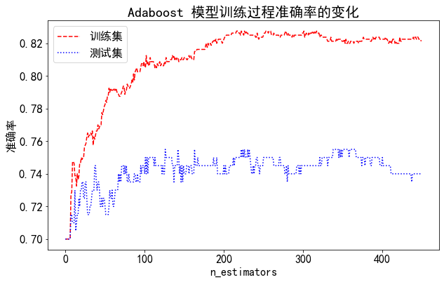

```python
## 查看模型训练过程准确率的变化
## 取出训练过程中模型得分
n_estimators = ada_gsearch.best_params_['n_estimators']
per_train = list(ada_model_2_fit.staged_score(x_train, y_train))
per_test= list(ada_model_2_fit.staged_score(x_test, y_test))

## 预测准确率绘图
plt.figure(figsize=(10,6))
plt.plot(np.arange(0,n_estimators),per_train,'--',color ='r',label='训练集')
plt.plot(np.arange(0,n_estimators),per_test,':',color ='b',label='测试集')
plt.xticks( fontsize=16)
plt.yticks( fontsize=17)
plt.xlabel('n_estimators',fontsize=16)
plt.ylabel('准确率',fontsize=16)
plt.legend(fontsize=16)
plt.title('Adaboost 模型训练过程准确率的变化',fontsize=20)
plt.show()
```

### 4. 集成学习，串行 Boosting 框架 —> GBDT 梯度提升决策树 模型实战

梯度提升是 Boosting 框架的一种改进，在参数优化环节，梯度下降使得参数每一步优化都具有方向性，学习过程更有效率。

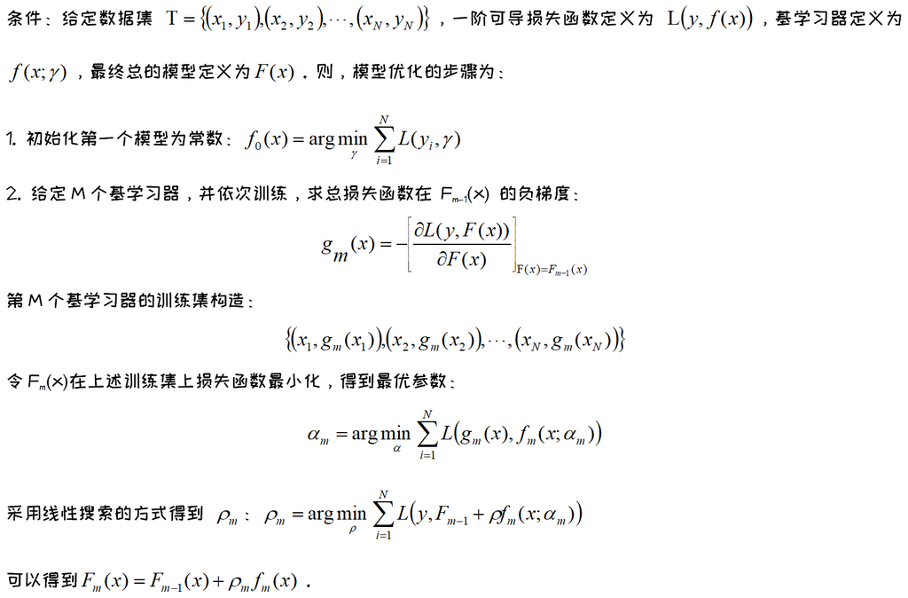

```python
## GBDT模型
## 设置待优化的超参数
gbdt_param = {'n_estimators': list(range(50, 400, 50)),
                'max_depth': list(range(2, 5, 1)),
                'learning_rate': list(np.arange(0.01, 0.5, 0.05)) }
## 初始化网格搜索
gbdt_gsearch = GridSearchCV(estimator=GradientBoostingClassifier( subsample=0.8,max_features=0.8, validation_fraction=0.1,
                                                                   n_iter_no_change =3,random_state=0),param_grid=gbdt_param,
                                                                   cv=3, scoring='f1', n_jobs=-1, verbose=2)
## 执行超参数优化
gbdt_gsearch.fit(x_train, y_train)
print('GBDT 模型最优得分 {0},\n最优参数{1}'.format(gbdt_gsearch.best_score_,gbdt_gsearch.best_params_))
```

```
Fitting 3 folds for each of 210 candidates, totalling 630 fits
```

```
[Parallel(n_jobs=-1)]: Using backend LokyBackend with 8 concurrent workers.
[Parallel(n_jobs=-1)]: Done  34 tasks      | elapsed:    0.9s
[Parallel(n_jobs=-1)]: Done 360 tasks      | elapsed:    3.2s
```

```
GBDT 模型最优得分 0.5068481126875287,
最优参数{'learning_rate': 0.46, 'max_depth': 2, 'n_estimators': 50}
```

```
[Parallel(n_jobs=-1)]: Done 630 out of 630 | elapsed:    4.2s finished
```

```python
## 模型训练
## 用最优参数，初始化GBDT模型
GBDT_model= GradientBoostingClassifier(subsample=0.8,max_features=0.8, validation_fraction=0.1,
                                                      n_iter_no_change =3,random_state=0 ,
                                        n_estimators=gbdt_gsearch.best_params_['n_estimators'],
                                        max_depth=gbdt_gsearch.best_params_['max_depth'],
                                        learning_rate=gbdt_gsearch.best_params_['learning_rate'])
## 训练GBDT模型
GBDT_model_fit = GBDT_model.fit(x_train, y_train)
```

```python
## 模型预测
y_pred = GBDT_model_fit.predict(x_test)
## 计算混淆矩阵与recall、precision
cnf_matrix = pd.DataFrame(data=confusion_matrix(y_test, y_pred),
                          columns=['预测结果为正例','预测结果为反例'],index=['真实样本为正例','真实样本为反例'])
recall_value = recall_score(y_test, y_pred)
precision_value = precision_score(y_test, y_pred)
acc = accuracy_score(y_test, y_pred)
print('GBDT 模型的召回率：',recall_value)
print('GBDT 模型的精准率：',precision_value)
print('GBDT 模型预测的正确率:',acc)
print('='*80)
print('测试集的混淆矩阵：')
cnf_matrix
```

```
GBDT 模型的召回率： 0.4
GBDT 模型的精准率： 0.6
GBDT 模型预测的正确率: 0.74
================================================================================
测试集的混淆矩阵：
```

|  | 预测结果为正例 | 预测结果为反例 |
| --- | --- | --- |
| 真实样本为正例 | 124 | 16 |
| 真实样本为反例 | 36 | 24 |

### 5. 集成学习，串行 Boosting 框架 —> Xgboost 模型实战

Xgboost 在 GBDT 一阶导的基础上，增加了二阶导数信息来训练一个新的决策树。此外，Xgboost 在目标函数中加入了正则项，以此限制每棵树的结构以减少过拟合问题。

参考 Bagging 样本扰动与属性扰动的思想，Xgboost 支持在样本空间与属性空间中学习新的决策树；同时，与 GBDT 模型一样，Xgboost引入输出扰动，即新决策数模型的训练是总损失函数在 $F_{m-1}(x)$ 的一阶导数与二阶导数上训练得到的。

```python
## xgboost模型
## 设置待优化的超参数
xgb_param = {'max_depth': list(range(2, 6, 1)), 'min_child_weight': list(range(1, 4, 1)),
                'learning_rate': list(np.arange(0.01, 0.3, 0.05)), 'scale_pos_weight': list(range(1, 5, 1))}
## 初始化网格搜索
xgb_gsearch = GridSearchCV(
    estimator=XGBClassifier(random_state=0, n_estimators=500, subsample=0.8, colsample_bytree=0.8),
    param_grid=xgb_param, cv=3, scoring='f1', n_jobs=-1, verbose=2)

## 执行超参数优化
xgb_gsearch.fit(x_train, y_train)
print('xgboost 模型最优得分 {0},\n最优参数{1}'.format(xgb_gsearch.best_score_,xgb_gsearch.best_params_))
```

```
[Parallel(n_jobs=-1)]: Using backend LokyBackend with 8 concurrent workers.
```

```
Fitting 3 folds for each of 288 candidates, totalling 864 fits
```

```
[Parallel(n_jobs=-1)]: Done  25 tasks      | elapsed:    4.1s
[Parallel(n_jobs=-1)]: Done 146 tasks      | elapsed:   11.3s
[Parallel(n_jobs=-1)]: Done 349 tasks      | elapsed:   23.7s
[Parallel(n_jobs=-1)]: Done 632 tasks      | elapsed:   40.1s
[Parallel(n_jobs=-1)]: Done 864 out of 864 | elapsed:   54.0s finished
```

```
xgboost 模型最优得分 0.6200203598184166,
最优参数{'learning_rate': 0.01, 'max_depth': 4, 'min_child_weight': 3, 'scale_pos_weight': 2}
```

```python
## 用最优参数，初始化xgboost模型
xgboost_model = XGBClassifier(random_state=0, n_jobs=-1,
                                    n_estimators=500,
                                    max_depth=xgb_gsearch.best_params_['max_depth'],
                                    subsample=0.8, colsample_bytree=0.8,
                                    learning_rate=xgb_gsearch.best_params_['learning_rate'],
                                    scale_pos_weight=xgb_gsearch.best_params_['scale_pos_weight'])
## 训练xgboost模型
xgboost_model_fit = xgboost_model.fit(x_train, y_train)
```

```python
## 模型预测
y_pred = xgboost_model_fit.predict(x_test)

## 计算混淆矩阵与recall、precision
cnf_matrix = pd.DataFrame(data=confusion_matrix(y_test, y_pred),
                          columns=['预测结果为正例','预测结果为反例'],index=['真实样本为正例','真实样本为反例'])
recall_value = recall_score(y_test, y_pred)
precision_value = precision_score(y_test, y_pred)
acc = accuracy_score(y_test, y_pred)
print('xgboost 模型的召回率：',recall_value)
print('xgboost 模型的精准率：',precision_value)
print('xgboost 模型预测的正确率:',acc)
print('='*80)
print('测试集的混淆矩阵：')
cnf_matrix
```

```
xgboost 模型的召回率： 0.6166666666666667
xgboost 模型的精准率： 0.5362318840579711
xgboost 模型预测的正确率: 0.725
================================================================================
测试集的混淆矩阵：
```

|  | 预测结果为正例 | 预测结果为反例 |
| --- | --- | --- |
| 真实样本为正例 | 108 | 32 |
| 真实样本为反例 | 23 | 37 |

```python
## 给出概率预测结果
y_score_test = xgboost_model_fit.predict_proba(x_test)[:, 1]

## 计算fpr与tpr
fpr, tpr, thresholds = roc_curve(y_test, y_score_test)

## 计算AR、gini等
roc_auc = auc(fpr, tpr)
ks = max(tpr - fpr)
ar = 2*roc_auc-1
gini = ar
print('测试集的 AR/基尼系数为:',ar)
print('测试集的KS值为:',ks)
print('测试集的AUC值为:',roc_auc)
```

```
测试集的 AR/基尼系数为: 0.5538095238095238
测试集的KS值为: 0.4357142857142858
测试集的AUC值为: 0.7769047619047619
```

```
最大KS值: 0.4357142857142858
```

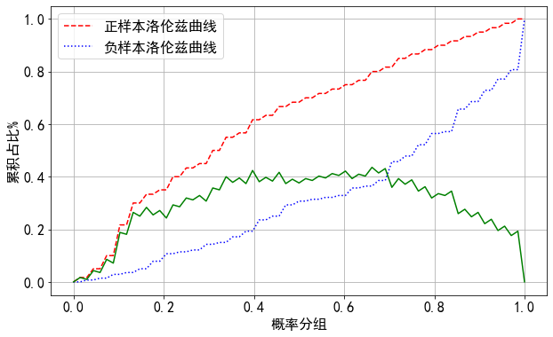

```python
## ks曲线
plt.figure(figsize=(10,6))
plt.plot(np.linspace(0,1,len(tpr)),tpr,'--',color='red', label='正样本洛伦兹曲线')
plt.plot(np.linspace(0,1,len(tpr)),fpr,':',color='blue', label='负样本洛伦兹曲线')
plt.plot(np.linspace(0,1,len(tpr)),tpr - fpr,'-',color='green')
plt.grid()
plt.xticks( fontsize=16)
plt.yticks( fontsize=16)
plt.xlabel('概率分组',fontsize=16)
plt.ylabel('累积占比%',fontsize=16)
plt.legend(fontsize=16)
print('最大KS值:',max(tpr - fpr))
```

```python
# 保存决策树图片
graph = Source.from_file(os.path.join(IMAGES_PATH,'RF_'+'0'+'.dot'))
graph.render('images/decision_trees/RF_50', format='png')
graph = Source.from_file(os.path.join(IMAGES_PATH,'RF_'+'50'+'.dot'))
graph.render('images/decision_trees/RF_0', format='png')
graph = Source.from_file(os.path.join(IMAGES_PATH,'RF_'+'99'+'.dot'))
graph.render('images/decision_trees/RF_99', format='png')
```

```
'images/decision_trees\\RF_99.png'
```